# AnaliseVinhos

Marcelo Bracali

31/07/2019

# 1 INFORMAÇÕES SOBRE O DATASET

O dataset multipropriedade, fornecido para análise compreende duas amostras de vinhos (Brancos e Tintos), do vinho “Vinho Verde” do norte de Portugal, e suas propriedades quimicas e físicas. Esse dataset foi doado em 7 de outubro de 2009.

Por questões de privacidade e logística, apenas as variáveis físico-químicas (insumos) e sensoriais (a saída) estão disponíveis (por exemplo, não há dados sobre tipos de uva, marca de vinho, preço de venda do vinho, etc.).

Fonte: Paulo Cortez, University of Minho, Guimarães, Portugal, http://www3.dsi.uminho.pt/pcortez A. Cerdeira, F. Almeida, T. Matos and J. Reis, Viticulture Commission of the Vinho Verde Region(CVRVV), Porto, Portugal @2009.

## 1.1 Características do dataset “vinhos”

O dataset, aqui nomeado de ‘vinhos’, onde foi carregada a base de dados fornecida, possui as seguintes características:

```
## 14 colunas e 6497 linhas.
```

```
## Sendo suas propriedades: id_vinho, fixedacidity, volatileacidity, citricacid, residualsugar, chlorides, freesulfurdioxide, totalsulfurdioxide, density, pH, sulphates, alcohol, quality, Vinho
```

Analisando as propriedades do dataset, percebemos a necessidade de qualificar de forma discreta os vinhos pelos seu fatores de qualidade. Dessa forma, criamos algumas categorias conforme descrito abaixo:

```r
#vinhos$quality.factor <- factor(vinhos$quality)
vinhos$quality.cat <- NA
vinhos$quality.cat <- ifelse(as.numeric(as.character(vinhos$quality)) >= 7, 'good', NA)
vinhos$quality.cat <- ifelse(as.numeric(as.character(vinhos$quality)) == 6, 'medium', vinhos$quality.cat)
vinhos$quality.cat <- ifelse(as.numeric(as.character(vinhos$quality)) == 5, 'medium', vinhos$quality.cat)
vinhos$quality.cat <- ifelse(as.numeric(as.character(vinhos$quality)) <= 4, 'bad', vinhos$quality.cat)
vinhos$quality.cat <- factor(vinhos$quality.cat, levels = c("bad", "medium", "good"))
```

Também entendemos que as propriedades “fixedacidity”, “volatileacidity” e “citricacid” compoem a acidez total do vinho. Dessa forma, geramos uma nova propriedade chamada “totalacidity” para sumariza-las.

```r
vinhos$totalacidity <- with(vinhos, fixedacidity + volatileacidity + citricacid)
```

Para compararmos os dois tipos de vinhos, criaremos dois vetores, aqui denominados vinhosBrancos e vinhosTintos.

```r
vinhos %>% filter(vinhos$Vinho == "WHITE") -> vinhosBrancos
vinhos %>% filter(vinhos$Vinho == "RED") -> vinhosTintos
```

Após criarmos esses dois novos vetores, obtivemos:

```
## Quantidade de propriedades: 16
```

```
## Sendo suas propriedades: id_vinho, fixedacidity, volatileacidity, citricacid, residualsugar, chlorides, freesulfurdioxide, totalsulfurdioxide, density, pH, sulphates, alcohol, quality, Vinho, quality.cat, totalacidity
```

```
## Quantidade de linhas para Vinhos Brancos: 4898
```

```
## Quantidade de linhas para Vinhos Tintos: 1599
```

## 1.2 Identificação das propriedades dos dois tipos de vinhos

### 1.2.1 Identificador do vinho - [1] “id_vinho”:

### 1.2.2 Acidez Fixa (g/dm^3) - [2] “fixedacidity”:

a maioria dos ácidos presentes no vinho ou fixos ou não voláteis (não evaporaram prontamente)

Os ácidos são os principais constituintes do vinho e contribuem grandemente para o seu sabor. De fato, os ácidos transmitem a acidez que é uma característica fundamental no gosto do vinho. Vinhos sem ácido são “planos”. Quimicamente, os ácidos influenciam a acidez titulável que afeta o sabor e o pH, o que afeta a cor, a estabilidade à oxidação e, consequentemente, a vida útil de um vinho. Os mais abundantes destes ácidos surgem nas próprias uvas e são transportados para o vinho.

Tradicionalmente, a acidez total é dividida em dois grupos, a saber, os ácidos voláteis (ver descrição em separado) e os ácidos não voláteis ou fixos.

Os ácidos fixos predominantes encontrados nos vinhos são tartárico, málico, cítrico e succínico. Seus respectivos níveis encontrados no vinho podem variar muito, mas em geral se esperaria ver 1.000 a 4.000 mg / L de ácido tartárico, 0 a 8.000 mg / L de ácido málico, 0 a 500 mg / L de ácido cítrico e 500 a 2.000 mg / l L ácido succínico. Todos esses ácidos são originários de uvas, com exceção do ácido succínico, que é produzido pela levedura durante o processo de fermentação. As uvas também contêm ácido ascórbico (vitamina C), mas isso é perdido durante a fermentação. Também é legal adicionar o ácido fumárico como conservante.

Os vinhos produzidos a partir de uvas de clima fresco são ricos em acidez e, portanto, têm sabor azedo. Estes vinhos de alta acidez podem ser tratados para reduzir a acidez, seja por agentes neutralizantes, seja por fermentação maloláctica. As uvas de clima quente podem ser baixas em ácido, mais ou menos dependendo da variedade. Nestas áreas é adicionado ácido tartárico, reciclado a partir de vinificação, para aumentar a acidez e evitar que os vinhos sejam planos. Atualmente, os produtores de vinho da Califórnia estão levando os vinhos a níveis elevados de pH, chegando a 4,0, enquanto 20 anos atrás, o pH acima de 3,6 era incomum. Isso torna os vinhos mais suaves, populares entre os escritores de vinhos de hoje.

Fonte: https://waterhouse.ucdavis.edu/whats-in-wine/fixed-acidity

```
## Descriptive Statistics
## vinhosBrancos.semOutliers$fixedacidity
## N: 4898
##
##                     fixedacidity
## ----------------- --------------
##              Mean           6.85
##           Std.Dev           0.84
##               Min           3.80
##                Q1           6.30
##            Median           6.80
##                Q3           7.30
##               Max          14.20
##               MAD           0.74
##               IQR           1.00
##                CV           0.12
##          Skewness           0.65
##       SE.Skewness           0.03
##          Kurtosis           2.17
##           N.Valid        4898.00
##         Pct.Valid         100.00
```

```
## Descriptive Statistics
## vinhosTintos.semOutliers$fixedacidity
## N: 1599
##
##                     fixedacidity
## ----------------- --------------
##              Mean           8.32
##           Std.Dev           1.74
##               Min           4.60
##                Q1           7.10
##            Median           7.90
##                Q3           9.20
##               Max          15.90
##               MAD           1.48
##               IQR           2.10
##                CV           0.21
##          Skewness           0.98
##       SE.Skewness           0.06
##          Kurtosis           1.12
##           N.Valid        1599.00
##         Pct.Valid         100.00
```

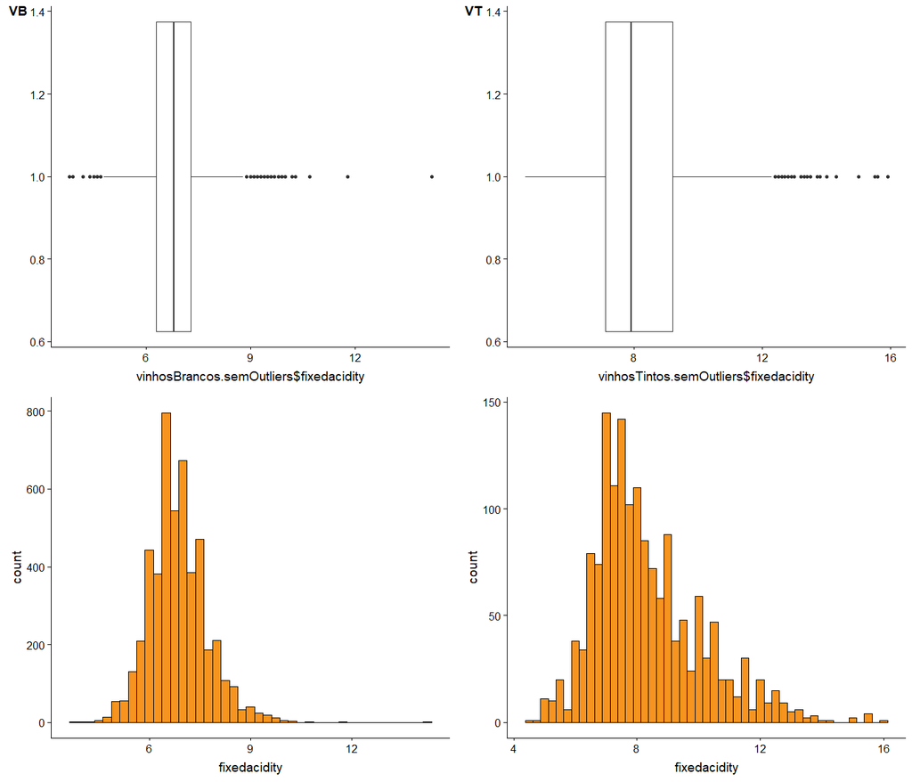

Vemos aqui que os dados da propriedade fixedacidity (Acidez Fixa) são normalmente distribuídos.

### 1.2.3 Acidez Voláil (g/dm^3) - [3] “volatileacidity”:

a quantidade de ácido acético no vinho, que em níveis muito altos pode levar a um gosto desagradável de vinagre.

```
## Descriptive Statistics
## vinhosBrancos.semOutliers$volatileacidity
## N: 4898
##
##                     volatileacidity
## ----------------- -----------------
##              Mean              0.28
##           Std.Dev              0.10
##               Min              0.08
##                Q1              0.21
##            Median              0.26
##                Q3              0.32
##               Max              1.10
##               MAD              0.09
##               IQR              0.11
##                CV              0.36
##          Skewness              1.58
##       SE.Skewness              0.03
##          Kurtosis              5.08
##           N.Valid           4898.00
##         Pct.Valid            100.00
```

```
## Descriptive Statistics
## vinhosTintos.semOutliers$volatileacidity
## N: 1599
##
##                     volatileacidity
## ----------------- -----------------
##              Mean              0.53
##           Std.Dev              0.18
##               Min              0.12
##                Q1              0.39
##            Median              0.52
##                Q3              0.64
##               Max              1.58
##               MAD              0.18
##               IQR              0.25
##                CV              0.34
##          Skewness              0.67
##       SE.Skewness              0.06
##          Kurtosis              1.21
##           N.Valid           1599.00
##         Pct.Valid            100.00
```

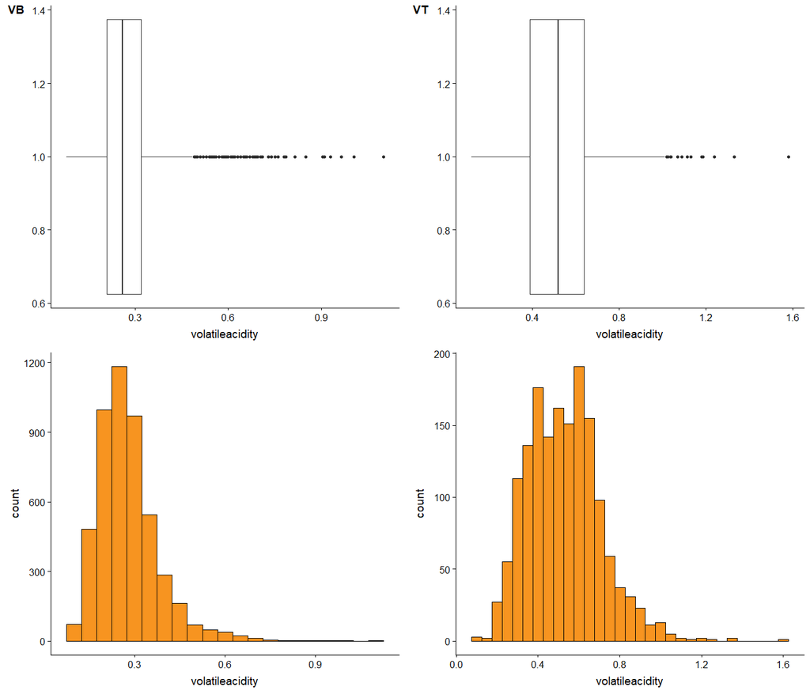

### 1.2.4 Ácido Cítrico (g/dm^3) - [4] “citricacid”:

encontrado em pequenas quantidades, o ácido cítrico pode adicionar “frescura” e sabor aos vinhos.

```
## Descriptive Statistics
## vinhosBrancos.semOutliers$citricacid
## N: 4898
##
##                     citricacid
## ----------------- ------------
##              Mean         0.33
##           Std.Dev         0.12
##               Min         0.00
##                Q1         0.27
##            Median         0.32
##                Q3         0.39
##               Max         1.66
##               MAD         0.09
##               IQR         0.12
##                CV         0.36
##          Skewness         1.28
##       SE.Skewness         0.03
##          Kurtosis         6.16
##           N.Valid      4898.00
##         Pct.Valid       100.00
```

```
## Descriptive Statistics
## vinhosTintos.semOutliers$citricacid
## N: 1599
##
##                     citricacid
## ----------------- ------------
##              Mean         0.27
##           Std.Dev         0.19
##               Min         0.00
##                Q1         0.09
##            Median         0.26
##                Q3         0.42
##               Max         1.00
##               MAD         0.25
##               IQR         0.33
##                CV         0.72
##          Skewness         0.32
##       SE.Skewness         0.06
##          Kurtosis        -0.79
##           N.Valid      1599.00
##         Pct.Valid       100.00
```

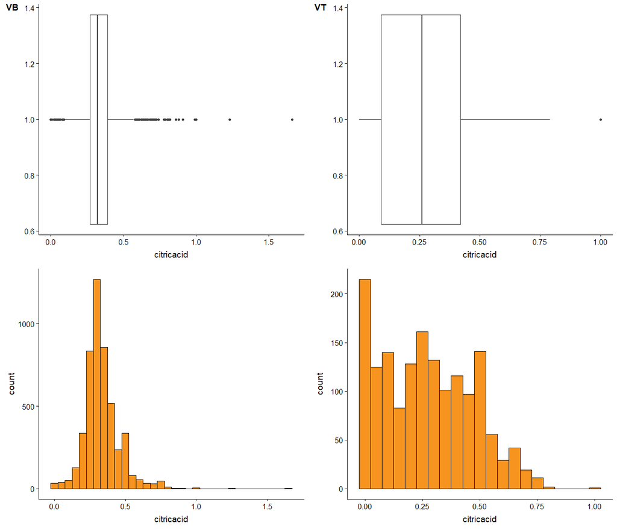

### 1.2.5 Açúcar Residual (g/dm^3) - [5] “residualsugar”:

a quantidade de açúcar restante depois que o processo de fermentação (em contato com a levedura, o açúcar da uva vai se transformando em álcool, ou seja, a fermentação vai ocorrendo)

```
## Descriptive Statistics
## vinhosBrancos$residualsugar
## N: 4898
##
##                     residualsugar
## ----------------- ---------------
##              Mean            6.39
##           Std.Dev            5.03
##               Min            0.60
##                Q1            1.70
##            Median            5.20
##                Q3            9.90
##               Max           45.80
##               MAD            5.34
##               IQR            8.20
##                CV            0.79
##          Skewness            0.87
##       SE.Skewness            0.03
##          Kurtosis            0.47
##           N.Valid         4898.00
##         Pct.Valid          100.00
```

```
## Descriptive Statistics
## vinhosTintos$residualsugar
## N: 1599
##
##                     residualsugar
## ----------------- ---------------
##              Mean            2.54
##           Std.Dev            1.41
##               Min            0.90
##                Q1            1.90
##            Median            2.20
##                Q3            2.60
##               Max           15.50
##               MAD            0.44
##               IQR            0.70
##                CV            0.56
##          Skewness            4.53
##       SE.Skewness            0.06
##          Kurtosis           28.49
##           N.Valid         1599.00
##         Pct.Valid          100.00
```

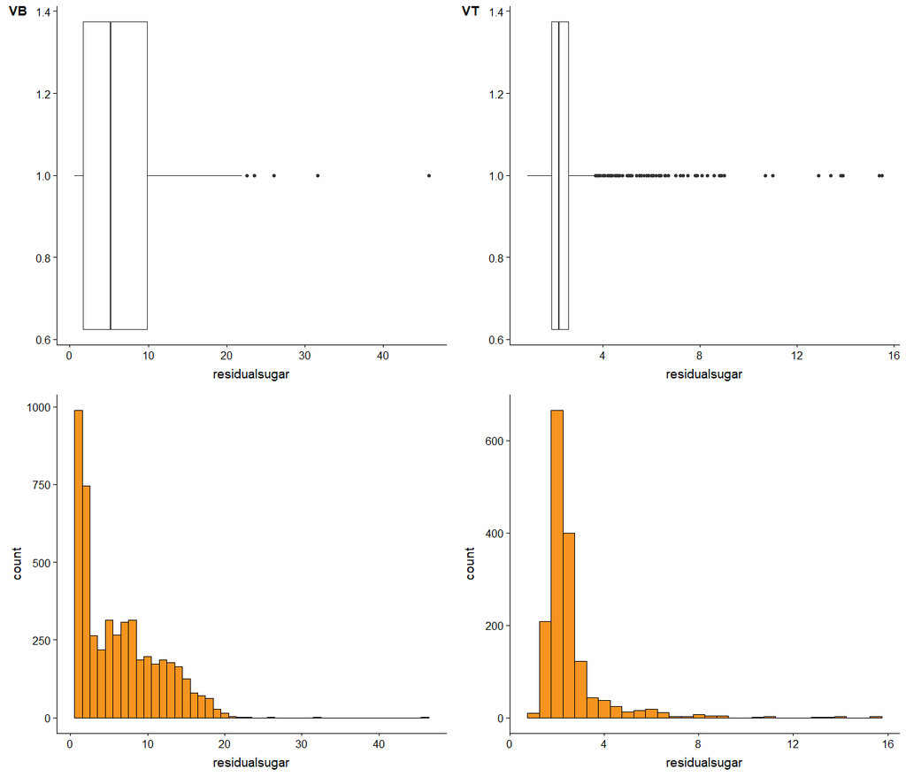

Ao comparar-mos o valor máximo de açucar residual com o terceiro quartil, há um enorme diferencial que pode ser observável. Isto é provavelmente devido a outliers.

Dessa forma, iremos remover alguns outliers nos dois tipos de vinhos conforme abaixo:

```r
vinhosBrancos.semOutliers = vinhosBrancos[vinhosBrancos.semOutliers$residualsugar < 30, ]
vinhosTintos.semOutliers = vinhosTintos[vinhosTintos$residualsugar < 10, ]
```

Os gráficos abaixo foram gerados sem os outliers:

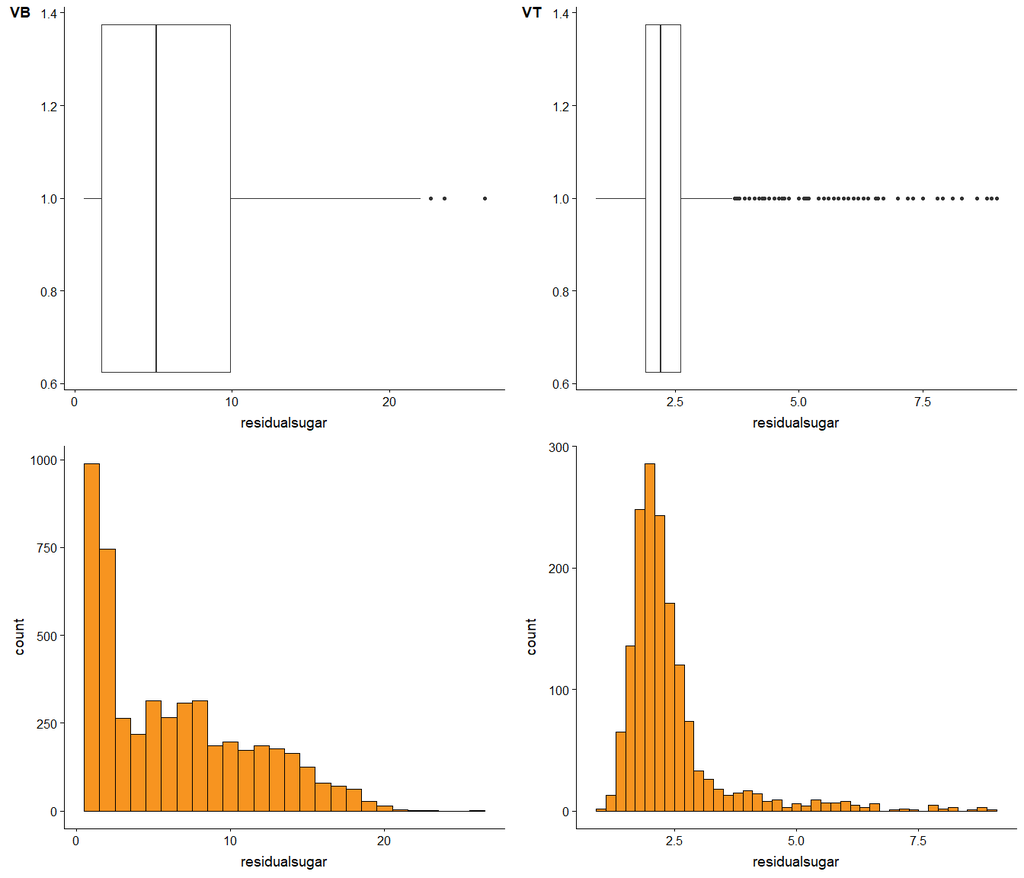

E exibir novamente as estatisticas sobre eles, permitindo observar que a remoção dos outliers nos da uma visualização muito melhor sobre a distribuição dos dados.

```
## Descriptive Statistics
## vinhosBrancos.semOutliers$residualsugar
## N: 4895
##
##                     residualsugar
## ----------------- ---------------
##              Mean            6.37
##           Std.Dev            4.98
##               Min            0.60
##                Q1            1.70
##            Median            5.20
##                Q3            9.90
##               Max           26.05
##               MAD            5.34
##               IQR            8.20
##                CV            0.78
##          Skewness            0.75
##       SE.Skewness            0.03
##          Kurtosis           -0.43
##           N.Valid         4895.00
##         Pct.Valid          100.00
```

```
## Descriptive Statistics
## vinhosTintos.semOutliers$residualsugar
## N: 1588
##
##                     residualsugar
## ----------------- ---------------
##              Mean            2.46
##           Std.Dev            1.08
##               Min            0.90
##                Q1            1.90
##            Median            2.20
##                Q3            2.60
##               Max            9.00
##               MAD            0.44
##               IQR            0.70
##                CV            0.44
##          Skewness            2.91
##       SE.Skewness            0.06
##          Kurtosis           10.30
##           N.Valid         1588.00
##         Pct.Valid          100.00
```

### 1.2.6 Cloretos (g/dm^3) - [6] “chlorides”:

a quantidade de sal no vinho.

```
## Descriptive Statistics
## vinhosBrancos.semOutliers$chlorides
## N: 4895
##
##                     chlorides
## ----------------- -----------
##              Mean        0.05
##           Std.Dev        0.02
##               Min        0.01
##                Q1        0.04
##            Median        0.04
##                Q3        0.05
##               Max        0.35
##               MAD        0.01
##               IQR        0.01
##                CV        0.48
##          Skewness        5.02
##       SE.Skewness        0.03
##          Kurtosis       37.52
##           N.Valid     4895.00
##         Pct.Valid      100.00
```

```
## Descriptive Statistics
## vinhosTintos.semOutliers$chlorides
## N: 1588
##
##                     chlorides
## ----------------- -----------
##              Mean        0.09
##           Std.Dev        0.05
##               Min        0.01
##                Q1        0.07
##            Median        0.08
##                Q3        0.09
##               Max        0.61
##               MAD        0.01
##               IQR        0.02
##                CV        0.54
##          Skewness        5.77
##       SE.Skewness        0.06
##          Kurtosis       42.82
##           N.Valid     1588.00
##         Pct.Valid      100.00
```

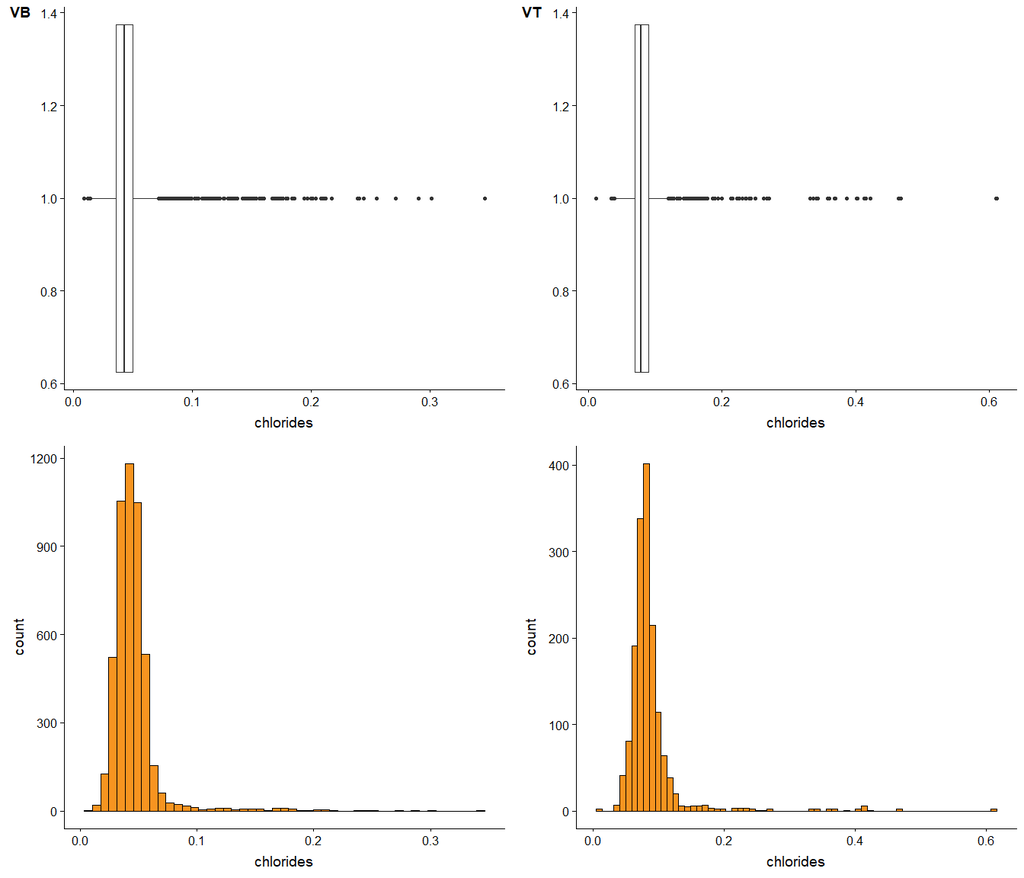

### 1.2.7 Livre de Dióxido de Enxofre (g/dm^3) - [7] “freesulfurdioxide”:

a forma livre de SO2 existe em equilíbrio entre o SO2 molecular (como gás dissolvido) e o íon bissulfito; impede o crescimento microbiano e a oxidação do vinho. Garante condições melhores para os processos de vinificação da bebida, elimina bactérias e leveduras frágeis e indesejáveis, o que permite que apenas as melhores prossigam com o processo fermentativo. Além do mais, melhora o aroma e afina a cor da bebida

```
## Descriptive Statistics
## vinhosBrancos$freesulfurdioxide
## N: 4898
##
##                     freesulfurdioxide
## ----------------- -------------------
##              Mean               35.31
##           Std.Dev               17.01
##               Min                2.00
##                Q1               23.00
##            Median               34.00
##                Q3               46.00
##               Max              289.00
##               MAD               16.31
##               IQR               23.00
##                CV                0.48
##          Skewness                1.41
##       SE.Skewness                0.03
##          Kurtosis               11.45
##           N.Valid             4898.00
##         Pct.Valid              100.00
```

```
## Descriptive Statistics
## vinhosTintos$freesulfurdioxide
## N: 1599
##
##                     freesulfurdioxide
## ----------------- -------------------
##              Mean               15.87
##           Std.Dev               10.46
##               Min                1.00
##                Q1                7.00
##            Median               14.00
##                Q3               21.00
##               Max               72.00
##               MAD               10.38
##               IQR               14.00
##                CV                0.66
##          Skewness                1.25
##       SE.Skewness                0.06
##          Kurtosis                2.01
##           N.Valid             1599.00
##         Pct.Valid              100.00
```

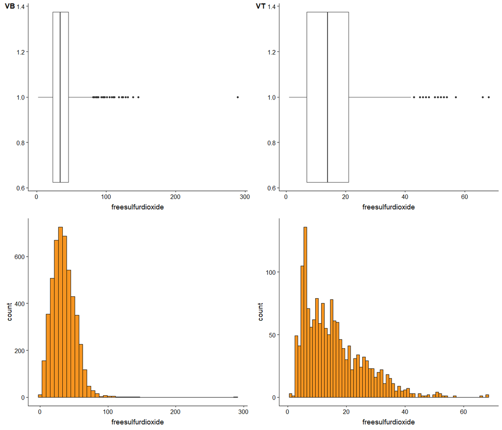

Os dados na propriedade freesulfurdioxide (Livre de Dióxido de Enxofre) são normalmente distribuídos.

No entanto, também existem alguns outliers potenciais, para os Vinhos Brancos quando se compara o valor máximo com o terceiro quartil. Portanto, os valores extremos serão removidos.

Dessa forma, iremos remover alguns outliers apenas dos Vinhos Brancos conforme abaixo:

```r
vinhosBrancos.semOutliers = vinhosBrancos.semOutliers[vinhosBrancos.semOutliers$freesulfurdioxide < 200, ]
```

Os gráficos abaixo foram gerados sem os outliers:

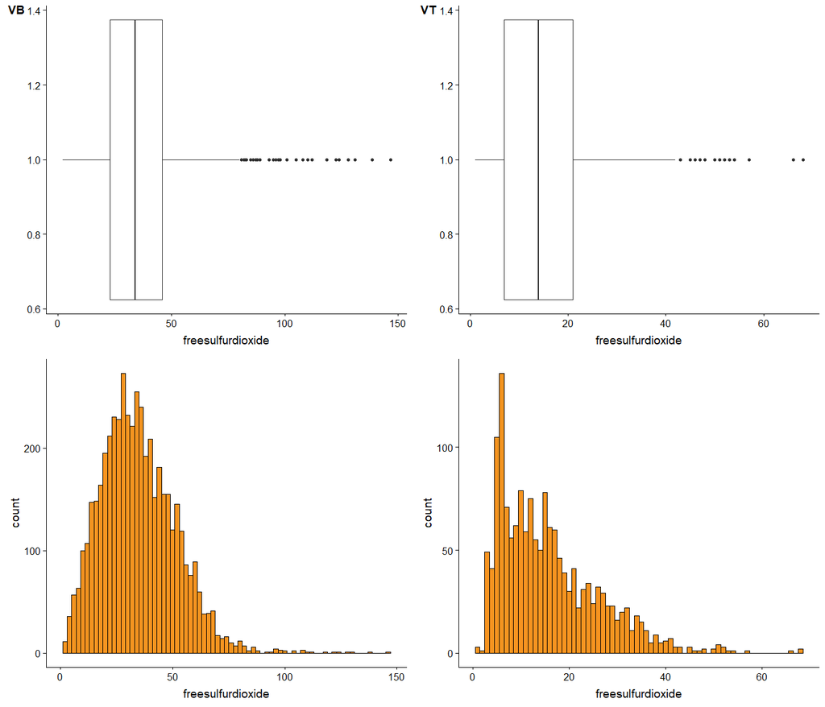

E exibir novamente as estatisticas sobre eles, permitindo observar que a remoção dos outliers nos da uma visualização muito melhor sobre a distribuição dos dados.

```
## Descriptive Statistics
## vinhosBrancos.semOutliers$freesulfurdioxide
## N: 4894
##
##                     freesulfurdioxide
## ----------------- -------------------
##              Mean               35.26
##           Std.Dev               16.62
##               Min                2.00
##                Q1               23.00
##            Median               34.00
##                Q3               46.00
##               Max              146.50
##               MAD               16.31
##               IQR               23.00
##                CV                0.47
##          Skewness                0.79
##       SE.Skewness                0.04
##          Kurtosis                1.77
##           N.Valid             4894.00
##         Pct.Valid              100.00
```

```
## Descriptive Statistics
## vinhosTintos.semOutliers$freesulfurdioxide
## N: 1588
##
##                     freesulfurdioxide
## ----------------- -------------------
##              Mean               15.75
##           Std.Dev               10.22
##               Min                1.00
##                Q1                7.00
##            Median               14.00
##                Q3               21.00
##               Max               68.00
##               MAD               10.38
##               IQR               14.00
##                CV                0.65
##          Skewness                1.16
##       SE.Skewness                0.06
##          Kurtosis                1.61
##           N.Valid             1588.00
##         Pct.Valid              100.00
```

### 1.2.8 Total de Dióxido de Enxofre (g/dm^3) - [8] “totalsulfurdioxide”:

quantidade de formas livres e encadernadas de S02; em baixas concentrações, o SO2 é quase indetectável no vinho, mas nas concentrações de SO2 livre acima de 50 ppm, o SO2 se torna evidente no nariz e no sabor do vinho.

```
## Descriptive Statistics
## vinhosBrancos$totalsulfurdioxide
## N: 4898
##
##                     totalsulfurdioxide
## ----------------- --------------------
##              Mean               138.36
##           Std.Dev                42.50
##               Min                 9.00
##                Q1               108.00
##            Median               134.00
##                Q3               167.00
##               Max               440.00
##               MAD                43.00
##               IQR                59.00
##                CV                 0.31
##          Skewness                 0.39
##       SE.Skewness                 0.03
##          Kurtosis                 0.57
##           N.Valid              4898.00
##         Pct.Valid               100.00
```

```
## Descriptive Statistics
## vinhosTintos$totalsulfurdioxide
## N: 1599
##
##                     totalsulfurdioxide
## ----------------- --------------------
##              Mean                46.47
##           Std.Dev                32.90
##               Min                 6.00
##                Q1                22.00
##            Median                38.00
##                Q3                62.00
##               Max               289.00
##               MAD                26.69
##               IQR                40.00
##                CV                 0.71
##          Skewness                 1.51
##       SE.Skewness                 0.06
##          Kurtosis                 3.79
##           N.Valid              1599.00
##         Pct.Valid               100.00
```

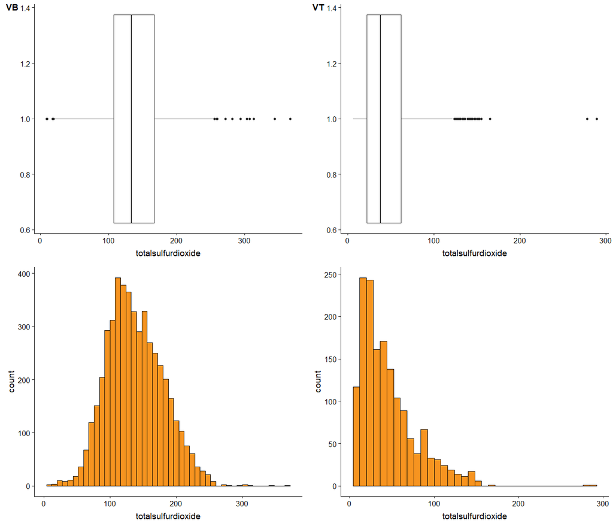

Os dados na propriedade totalsulfurdioxide (Total de Dióxido de Enxofre) são normalmente distribuídos.

### 1.2.9 Densidade (g/cm^3) - [9] “density”:

a densidade é próxima à da água, dependendo do percentual de álcool e teor de açúcar.

```
## Descriptive Statistics
## vinhosBrancos$density
## N: 4898
##
##                     density
## ----------------- ---------
##              Mean      0.99
##           Std.Dev      0.00
##               Min      0.99
##                Q1      0.99
##            Median      0.99
##                Q3      1.00
##               Max      1.01
##               MAD      0.00
##               IQR      0.00
##                CV      0.00
##          Skewness      0.37
##       SE.Skewness      0.03
##          Kurtosis     -0.02
##           N.Valid   4898.00
##         Pct.Valid    100.00
```

```
## Descriptive Statistics
## vinhosTintos$density
## N: 1599
##
##                     density
## ----------------- ---------
##              Mean      1.00
##           Std.Dev      0.00
##               Min      0.99
##                Q1      1.00
##            Median      1.00
##                Q3      1.00
##               Max      1.00
##               MAD      0.00
##               IQR      0.00
##                CV      0.00
##          Skewness      0.07
##       SE.Skewness      0.06
##          Kurtosis      0.92
##           N.Valid   1599.00
##         Pct.Valid    100.00
```

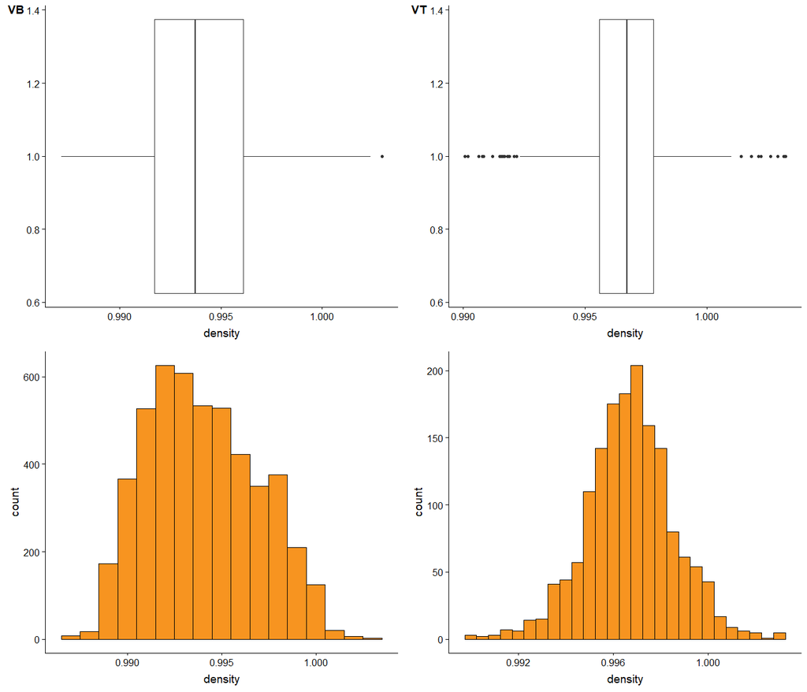

Os dados na propriedade density (Densidade) são normalmente distribuídos.

Dessa forma, iremos remover alguns outliers apenas dos Vinhos Brancos conforme abaixo:

```r
vinhosBrancos.semOutliers = vinhosBrancos.semOutliers[vinhosBrancos.semOutliers$density < 1.005, ]
```

Os gráficos abaixo foram gerados sem os outliers:

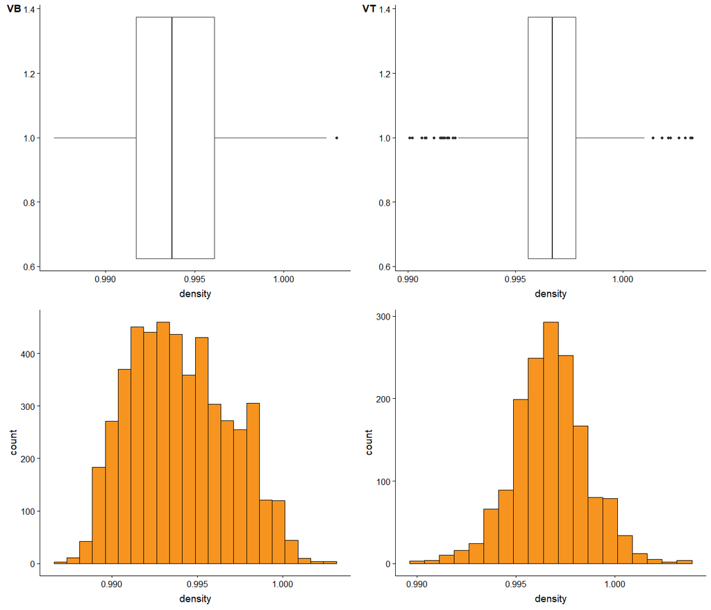

E exibir novamente as estatisticas sobre eles, permitindo observar que a remoção dos outliers nos da uma visualização muito melhor sobre a distribuição dos dados.

```
## Descriptive Statistics
## vinhosBrancos.semOutliers$density
## N: 4894
##
##                     density
## ----------------- ---------
##              Mean      0.99
##           Std.Dev      0.00
##               Min      0.99
##                Q1      0.99
##            Median      0.99
##                Q3      1.00
##               Max      1.00
##               MAD      0.00
##               IQR      0.00
##                CV      0.00
##          Skewness      0.25
##       SE.Skewness      0.04
##          Kurtosis     -0.74
##           N.Valid   4894.00
##         Pct.Valid    100.00
```

```
## Descriptive Statistics
## vinhosTintos.semOutliers$density
## N: 1588
##
##                     density
## ----------------- ---------
##              Mean      1.00
##           Std.Dev      0.00
##               Min      0.99
##                Q1      1.00
##            Median      1.00
##                Q3      1.00
##               Max      1.00
##               MAD      0.00
##               IQR      0.00
##                CV      0.00
##          Skewness     -0.03
##       SE.Skewness      0.06
##          Kurtosis      0.78
##           N.Valid   1588.00
##         Pct.Valid    100.00
```

### 1.2.10 pH - [10] “pH”:

descreve como o vinho é acídico ou básico numa escala de 0 (muito ácido) a 14 (muito básico); a maioria dos vinhos tem entre 3-4 na escala de pH.

```
## Descriptive Statistics
## vinhosBrancos.semOutliers$pH
## N: 4894
##
##                          pH
## ----------------- ---------
##              Mean      3.19
##           Std.Dev      0.15
##               Min      2.72
##                Q1      3.09
##            Median      3.18
##                Q3      3.28
##               Max      3.82
##               MAD      0.15
##               IQR      0.19
##                CV      0.05
##          Skewness      0.46
##       SE.Skewness      0.04
##          Kurtosis      0.53
##           N.Valid   4894.00
##         Pct.Valid    100.00
```

```
## Descriptive Statistics
## vinhosTintos.semOutliers$pH
## N: 1588
##
##                          pH
## ----------------- ---------
##              Mean      3.31
##           Std.Dev      0.15
##               Min      2.74
##                Q1      3.21
##            Median      3.31
##                Q3      3.40
##               Max      4.01
##               MAD      0.15
##               IQR      0.19
##                CV      0.05
##          Skewness      0.19
##       SE.Skewness      0.06
##          Kurtosis      0.80
##           N.Valid   1588.00
##         Pct.Valid    100.00
```

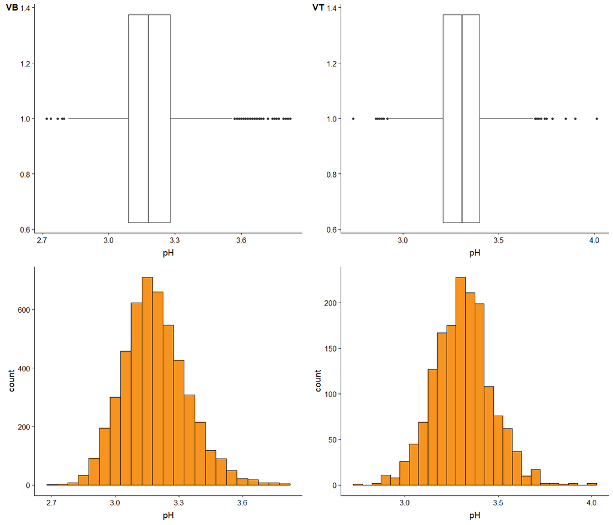

Os dados na propriedade pH são normalmente distribuídos. E se comparado com outras propriedades, os valores de pH mostram melhor distribuição gaussiana.

### 1.2.11 Sulfatos (g/dm^3) - [11] “sulphates”:

um aditivo de vinho que pode contribuir para os níveis de gás de dióxido de enxofre (S02), que age como um antimicrobiano e antioxidante.

```
## Descriptive Statistics
## vinhosBrancos.semOutliers$sulphates
## N: 4894
##
##                     sulphates
## ----------------- -----------
##              Mean        0.49
##           Std.Dev        0.11
##               Min        0.22
##                Q1        0.41
##            Median        0.47
##                Q3        0.55
##               Max        1.08
##               MAD        0.10
##               IQR        0.14
##                CV        0.23
##          Skewness        0.98
##       SE.Skewness        0.04
##          Kurtosis        1.59
##           N.Valid     4894.00
##         Pct.Valid      100.00
```

```
## Descriptive Statistics
## vinhosTintos.semOutliers$sulphates
## N: 1588
##
##                     sulphates
## ----------------- -----------
##              Mean        0.66
##           Std.Dev        0.17
##               Min        0.33
##                Q1        0.55
##            Median        0.62
##                Q3        0.73
##               Max        2.00
##               MAD        0.12
##               IQR        0.18
##                CV        0.26
##          Skewness        2.43
##       SE.Skewness        0.06
##          Kurtosis       11.63
##           N.Valid     1588.00
##         Pct.Valid      100.00
```

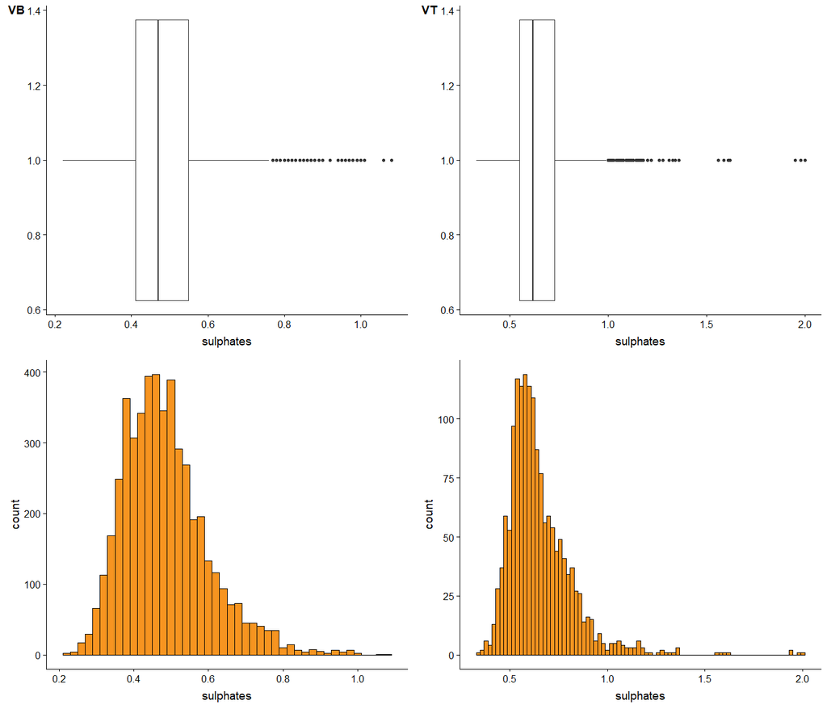

Os dados na propriedade sulphates (Sulfatos) são normalmente distribuídos.

### 1.2.12 Percentual alcólico (% by volume) - [12] “alcohol”:

o teor alcoólico percentual do vinho.

```
## Descriptive Statistics
## vinhosBrancos.semOutliers$alcohol
## N: 4894
##
##                     alcohol
## ----------------- ---------
##              Mean     10.51
##           Std.Dev      1.23
##               Min      8.00
##                Q1      9.50
##            Median     10.40
##                Q3     11.40
##               Max     14.20
##               MAD      1.48
##               IQR      1.90
##                CV      0.12
##          Skewness      0.49
##       SE.Skewness      0.04
##          Kurtosis     -0.70
##           N.Valid   4894.00
##         Pct.Valid    100.00
```

```
## Descriptive Statistics
## vinhosTintos.semOutliers$alcohol
## N: 1588
##
##                     alcohol
## ----------------- ---------
##              Mean     10.41
##           Std.Dev      1.16
##               Min      0.96
##                Q1      9.50
##            Median     10.20
##                Q3     11.10
##               Max     14.90
##               MAD      1.04
##               IQR      1.60
##                CV      0.11
##          Skewness     -0.61
##       SE.Skewness      0.06
##          Kurtosis      9.94
##           N.Valid   1588.00
##         Pct.Valid    100.00
```

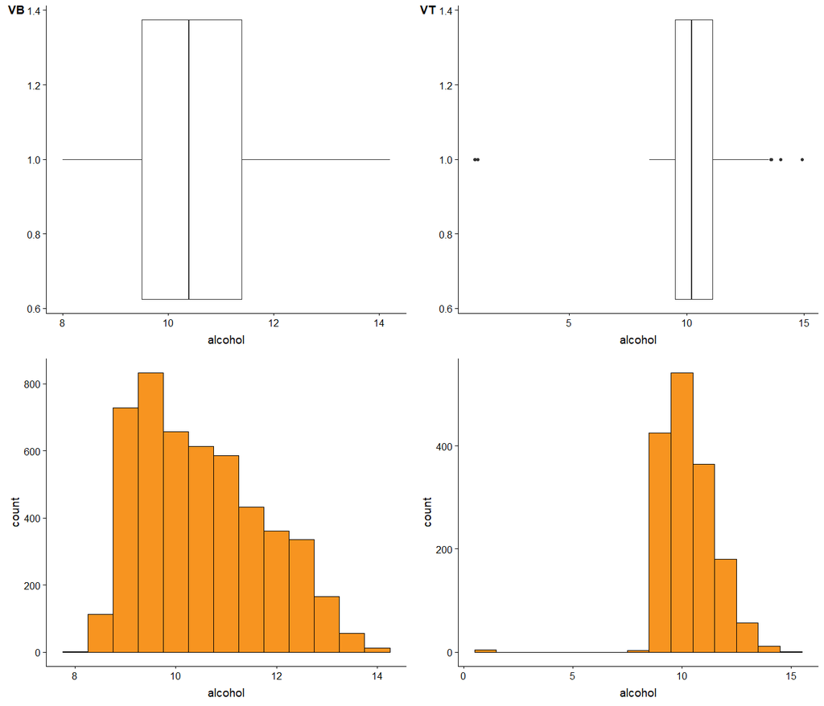

Os dados na propriedade alcohol (Álcool) demonstram uma distribuição distorcida, assim como os cloretos ou açucares residuais, mas aqui a assimetria é menor.

### 1.2.13 Qualidade do vinho - [13] “quality”:

propriedade de saída (com base em dados sensoriais) que poderiam ser de 0 a 10 sendo zero muito ruim e 10 muito excelente.

```
## Total de vinhos Brancos - Bons = 1060
## Total de vinhos Brancos - Médios = 3652
## Total de vinhos Brancos - Ruins = 182
```

```
## Total de vinhos Tintos - Bons = 217
## Total de vinhos Tintos - Médios = 1309
## Total de vinhos Tintos - Ruins = 62
```

Estes resultados demonstram que grande parte dos vinhos da base de dados é de qualidade média.

### 1.2.14 Tipo do Vinho - [14] “Vinho”:

```
## Total de vinhos Brancos = 4898
```

```
## Total de vinhos Tinto = 1599
```

### 1.2.15 Acidez total do vinho [15] “totalacidity”:

propriedade criada com base nas propriedades “fixedacidity”, “volatileacidity” e “citricacid” quem compoem a acidez total do vinho.

```
## Descriptive Statistics
## vinhosBrancos.semOutliers$totalacidity
## N: 4894
##
##                     totalacidity
## ----------------- --------------
##              Mean           7.47
##           Std.Dev           0.89
##               Min           4.13
##                Q1           6.89
##            Median           7.40
##                Q3           7.96
##               Max          14.96
##               MAD           0.79
##               IQR           1.07
##                CV           0.12
##          Skewness           0.65
##       SE.Skewness           0.04
##          Kurtosis           2.06
##           N.Valid        4894.00
##         Pct.Valid         100.00
```

```
## Descriptive Statistics
## vinhosTintos.semOutliers$totalacidity
## N: 1588
##
##                     totalacidity
## ----------------- --------------
##              Mean           9.12
##           Std.Dev           1.83
##               Min           5.27
##                Q1           7.83
##            Median           8.72
##                Q3          10.05
##               Max          17.05
##               MAD           1.53
##               IQR           2.22
##                CV           0.20
##          Skewness           0.97
##       SE.Skewness           0.06
##          Kurtosis           1.08
##           N.Valid        1588.00
##         Pct.Valid         100.00
```

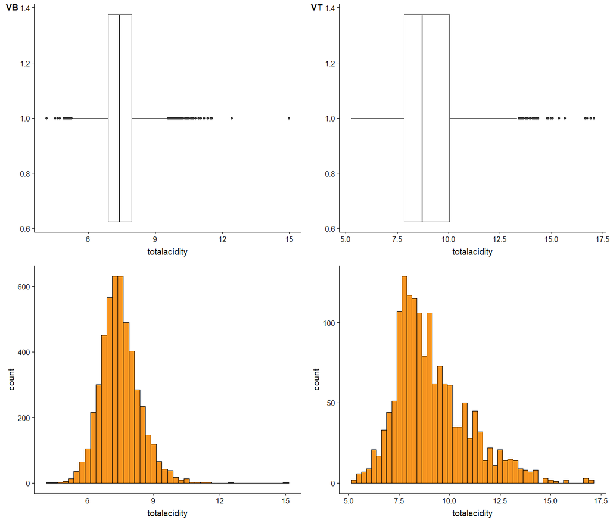

No entanto, também existem alguns outliers potenciais, para os Vinhos Brancos quando se compara o valor máximo com o terceiro quartil. Portanto, os valores extremos serão removidos.

Dessa forma, iremos remover alguns outliers apenas dos Vinhos Brancos conforme abaixo:

```r
vinhosBrancos.semOutliers = vinhosBrancos.semOutliers[vinhosBrancos.semOutliers$totalacidity < 12, ]
```

Os gráficos abaixo foram gerados sem os outliers:

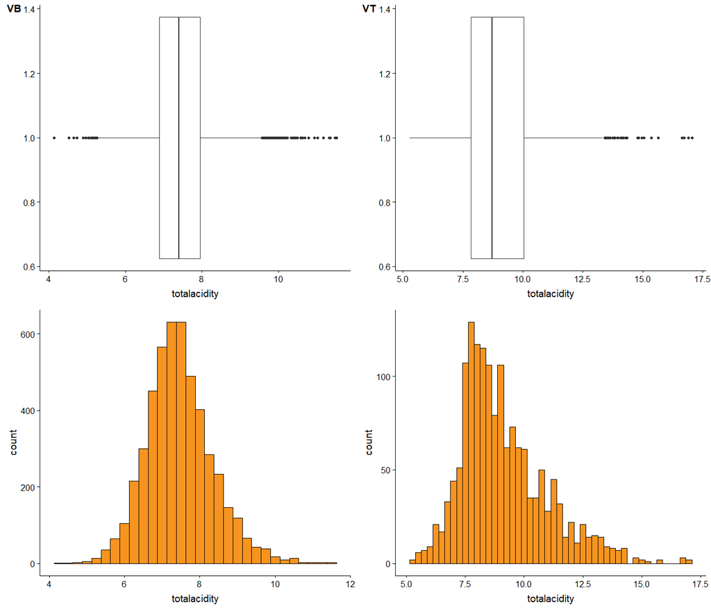

E exibir novamente as estatisticas sobre eles, permitindo observar que a remoção dos outliers nos da uma visualização muito melhor sobre a distribuição dos dados.

```
## Descriptive Statistics
## vinhosBrancos.semOutliers$totalacidity
## N: 4892
##
##                     totalacidity
## ----------------- --------------
##              Mean           7.46
##           Std.Dev           0.88
##               Min           4.13
##                Q1           6.89
##            Median           7.40
##                Q3           7.96
##               Max          11.52
##               MAD           0.79
##               IQR           1.07
##                CV           0.12
##          Skewness           0.51
##       SE.Skewness           0.04
##          Kurtosis           0.99
##           N.Valid        4892.00
##         Pct.Valid         100.00
```

```
## Descriptive Statistics
## vinhosTintos.semOutliers$totalacidity
## N: 1588
##
##                     totalacidity
## ----------------- --------------
##              Mean           9.12
##           Std.Dev           1.83
##               Min           5.27
##                Q1           7.83
##            Median           8.72
##                Q3          10.05
##               Max          17.05
##               MAD           1.53
##               IQR           2.22
##                CV           0.20
##          Skewness           0.97
##       SE.Skewness           0.06
##          Kurtosis           1.08
##           N.Valid        1588.00
##         Pct.Valid         100.00
```

## 1.3 Análise dos Dados

Para termos uma ideia geral dos dados, são listados abaixo apenas os 6 primeiros registros:

|  | id_vinho | fixedacidity | volatileacidity | citricacid | residualsugar | chlorides | freesulfurdioxide | totalsulfurdioxide | density | pH | sulphates | alcohol | quality | Vinho | quality.cat | totalacidity |
| --- | --- | --- | --- | --- | --- | --- | --- | --- | --- | --- | --- | --- | --- | --- | --- | --- |
| 1 | 1 | 6.6 | 0.24 | 0.35 | 7.70 | 0.031 | 36 | 135 | 0.99380 | 3.19 | 0.37 | 10.5 | 5 | WHITE | medium | 7.19 |
| 2 | 2 | 6.7 | 0.34 | 0.43 | 1.60 | 0.041 | 29 | 114 | 0.99014 | 3.23 | 0.44 | 12.6 | 6 | WHITE | medium | 7.47 |
| 3 | 3 | 10.6 | 0.31 | 0.49 | 2.20 | 0.063 | 18 | 40 | 0.99760 | 3.14 | 0.51 | 9.8 | 6 | RED | medium | 11.40 |
| 4 | 4 | 5.4 | 0.18 | 0.24 | 4.80 | 0.041 | 30 | 113 | 0.99445 | 3.42 | 0.40 | 9.4 | 6 | WHITE | medium | 5.82 |
| 5 | 5 | 6.7 | 0.30 | 0.44 | 18.75 | 0.057 | 65 | 224 | 0.99956 | 3.11 | 0.53 | 9.1 | 5 | WHITE | medium | 7.44 |
| 6 | 6 | 6.8 | 0.50 | 0.11 | 1.50 | 0.075 | 16 | 49 | 0.99545 | 3.36 | 0.79 | 9.5 | 5 | RED | medium | 7.41 |

### 1.3.1 Análise Bivariada

A partir da análise uni-variante na seção acima, reflete alguns insights de atributos individuais no conjunto de dados. Nesta seção, as correlações entre os atributos foram investigadas.

Para entender as relações entre os atributos, foi gerada a seguinte matriz de gráficos de correlação. A matriz de gráficos é vantajosa para esse tipo de análise, porque todas as relações entre as variáveis podem ser facilmente identificadas. É útil implementar uma análise adicional do conjunto de dados.

## 1.4 Correlation, Variance and Covariance (Matrices)

A seguir, iremos gerar um mapa de calor das correlações para cada tipo de vinho.

### 1.4.1 Vinhos Brancos:

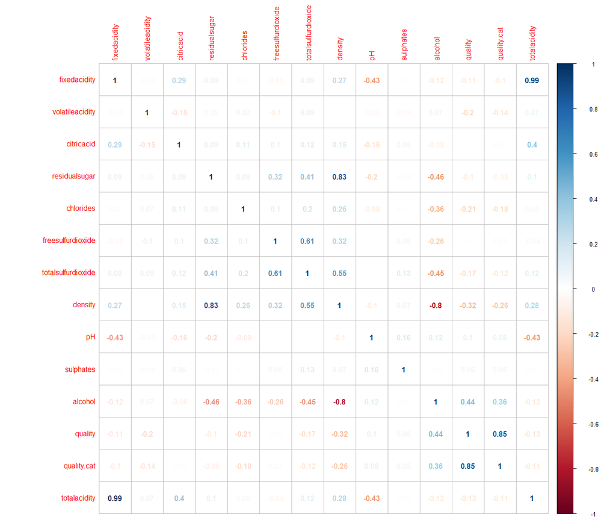

### 1.4.2 Vinhos Tintos:

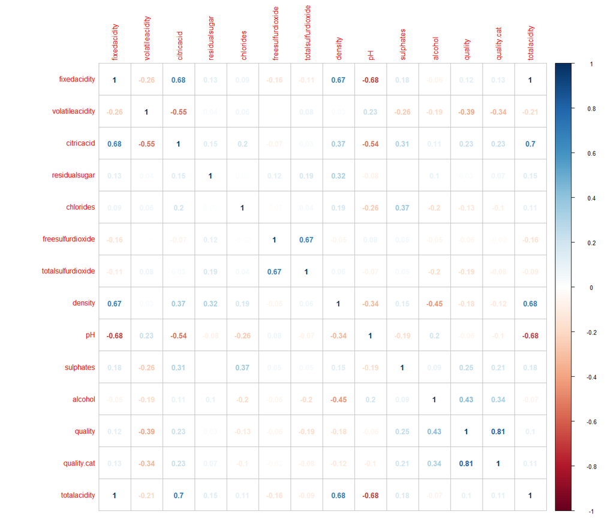

Quando se examina o coeficiente de correlação para cada relação nas figuras acima, alguns dos atributos parecem ser de alta a moderadamente correlacionados entre si.

### 1.4.3 Vinhos Brancos (Filtrado):

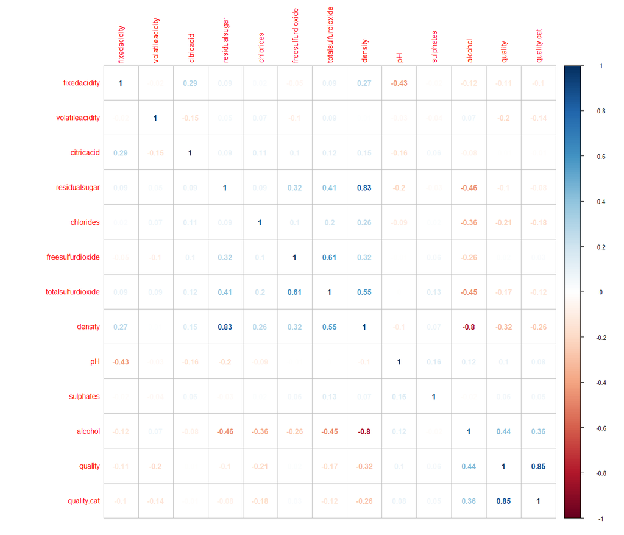

### 1.4.4 Vinhos Tintos (Filtrado):

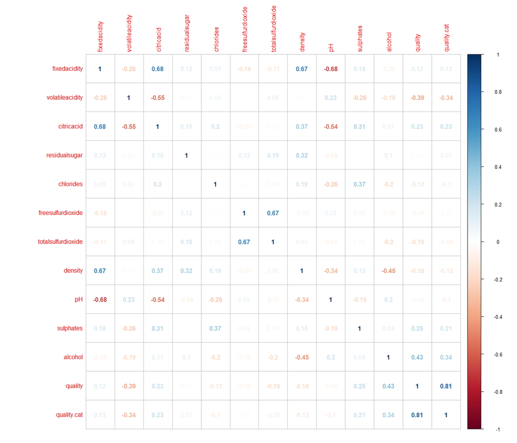

**Dessa forma, com os novos dados de correlação, temos:**

Por exemplo, para os Vinhos Brancos, os coeficientes de correlação das propriedadesabaixo são:  
**- Álcool (alcohol) vs Densidade (density) = -0.80**  
**- Açúcar Residual (residualsugar) vs Densidade (density) = 0.84**  
**- Dióxido de Enxofre Total (totalsulfurdioxide) vs Densidade (density) = 0.54**  
**- Dióxido de Enxofre Total (totalsulfurdioxide) vs Dióxido de Enxofre Livre (freesulfurdioxide) = 0.62**  
A correlação entre Dióxido de Enxofre Total (totalsulfurdioxide) e Dióxido de Enxofre Livre (freesulfurdioxide) será desconsiderada, devido ao fato de que uma propriedade compreende a outra.

Já para os Vinhos Tintos, os coeficientes de correlação são:  
**- pH vs Acidez Fixa (fixedacidity) = -0.68**  
**- pH vs Ácido Cítrico (citricacid) = -0.54**  
**- Densidade (density) vs Acidez Fixa (fixedacidity) = 0.67**  
**- Dióxido de Enxofre Total (totalsulfurdioxide) vs Dióxido de Enxofre Livre (freesulfurdioxide) = 0.67**  
A correlação entre Dióxido de Enxofre Total (totalsulfurdioxide) e Dióxido de Enxofre Livre (freesulfurdioxide) será desconsiderada, devido ao fato de que uma propriedade compreende a outra.  
**- Ácido Cítrico (citricacid) vs Acidez Fixa (fixedacidity) = 0.67**  
**- Ácido Cítrico (citricacid) vs Acidez Voláil (volatileacidity) = -0.55**

No entanto, se compararmos as correlações entre os dois tipos de vinhos temos:

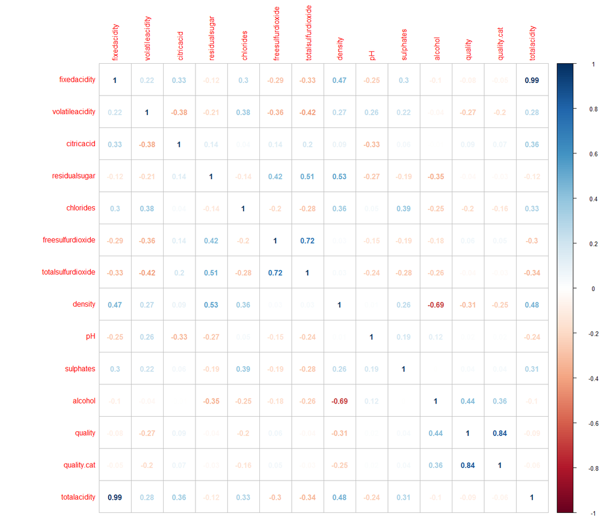

Nas seções abaixo, cada uma dessas relações de alta a moderada será investigada:

### 1.4.5 Vinhos Brancos (Análise das Correlações)

- **Álcool (alcohol) vs Densidade (density) = -0.80**

  O álcool tem correlação negativa com a densidade. Isto é evidente pelo fato de que a densidade da água é maior que a densidade do álcool.

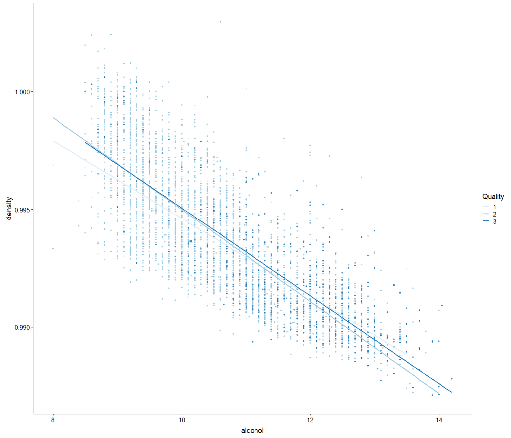

- **Açúcar Residual (residualsugar) vs Densidade (density) = 0.84**

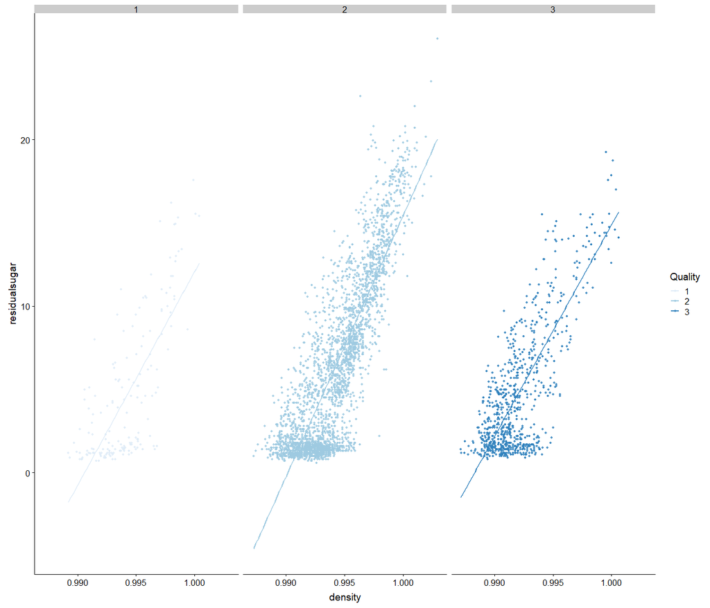

- **Dióxido de Enxofre Total (totalsulfurdioxide) vs Densidade (density) = 0.54**

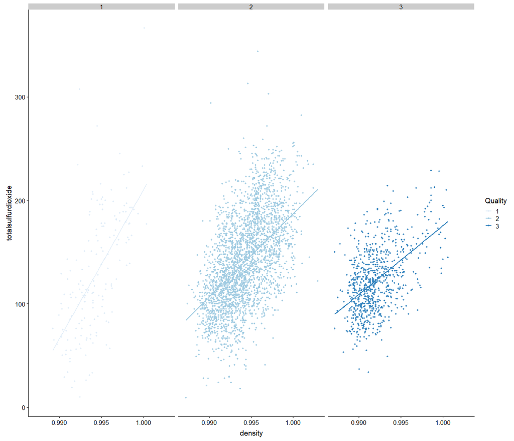

### 1.4.6 Vinhos Tintos (Análise das Correlações)

- **pH vs Acidez Fixa (fixedacidity) = -0.68**

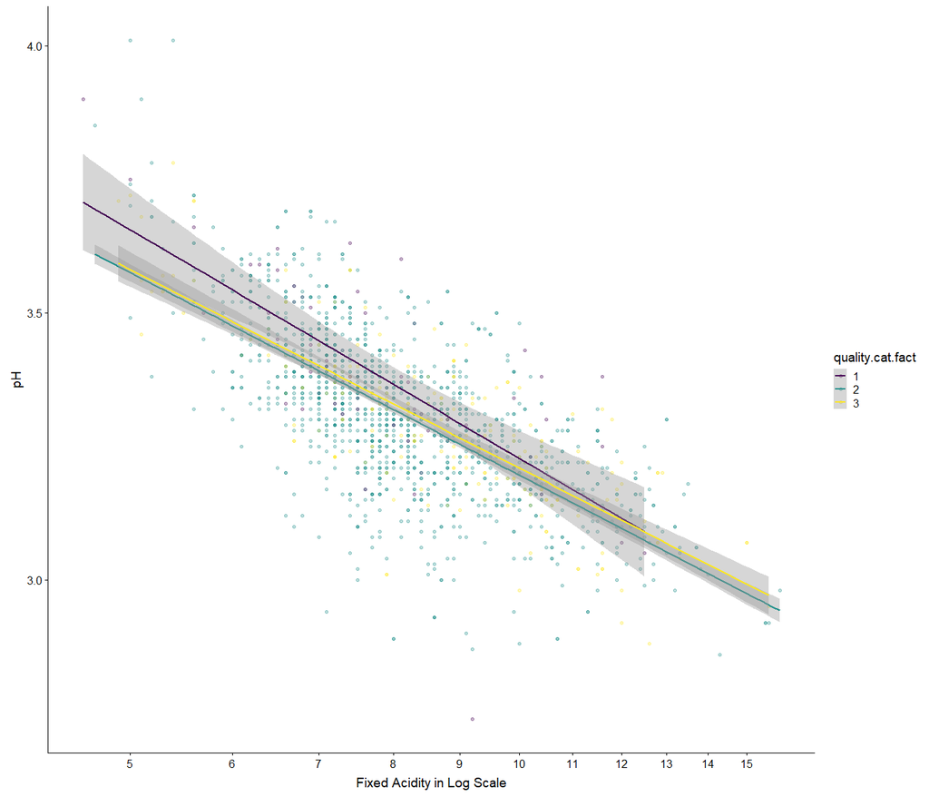

- **pH vs Ácido Cítrico (citricacid) = -0.54**

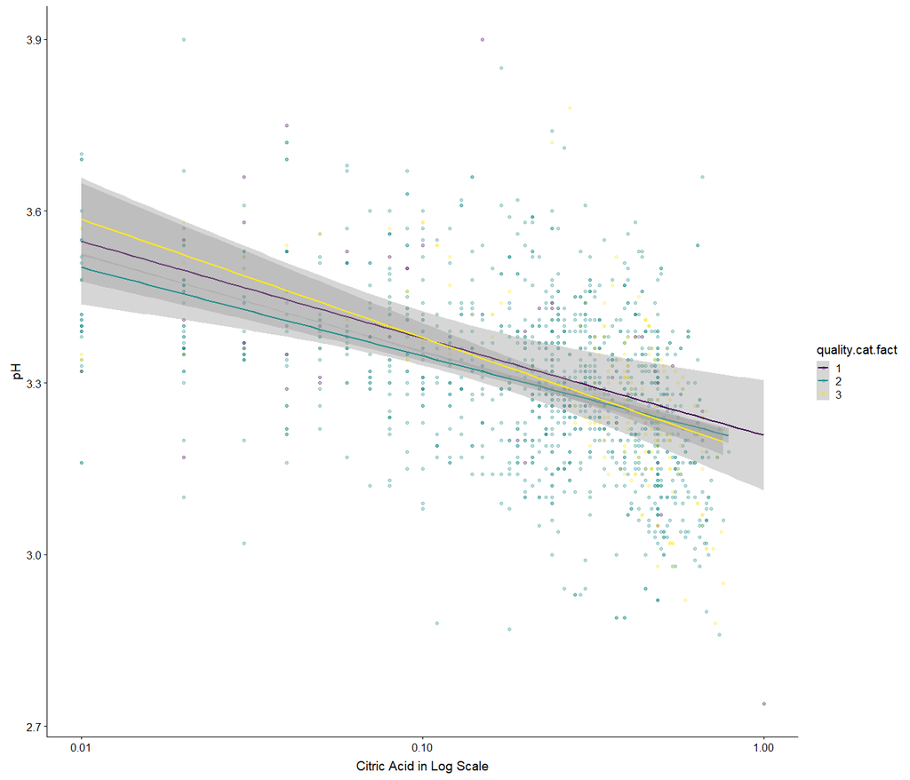

- **Densidade (density) vs Acidez Fixa (fixedacidity) = 0.67**

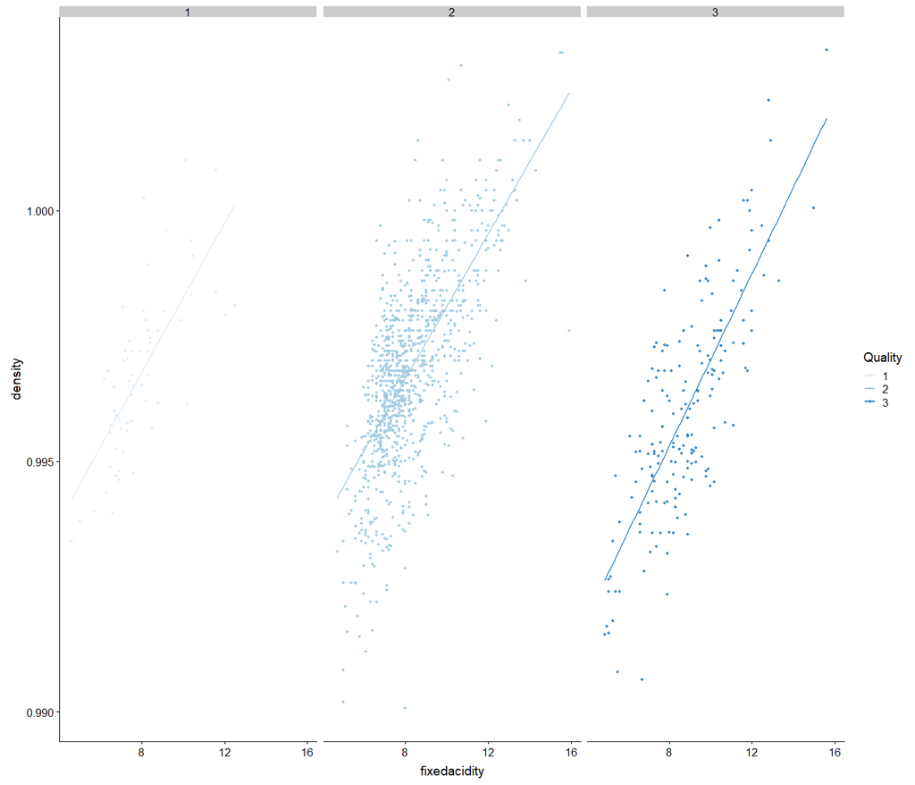

- **Ácido Cítrico (citricacid) vs Acidez Fixa (fixedacidity) = 0.67**

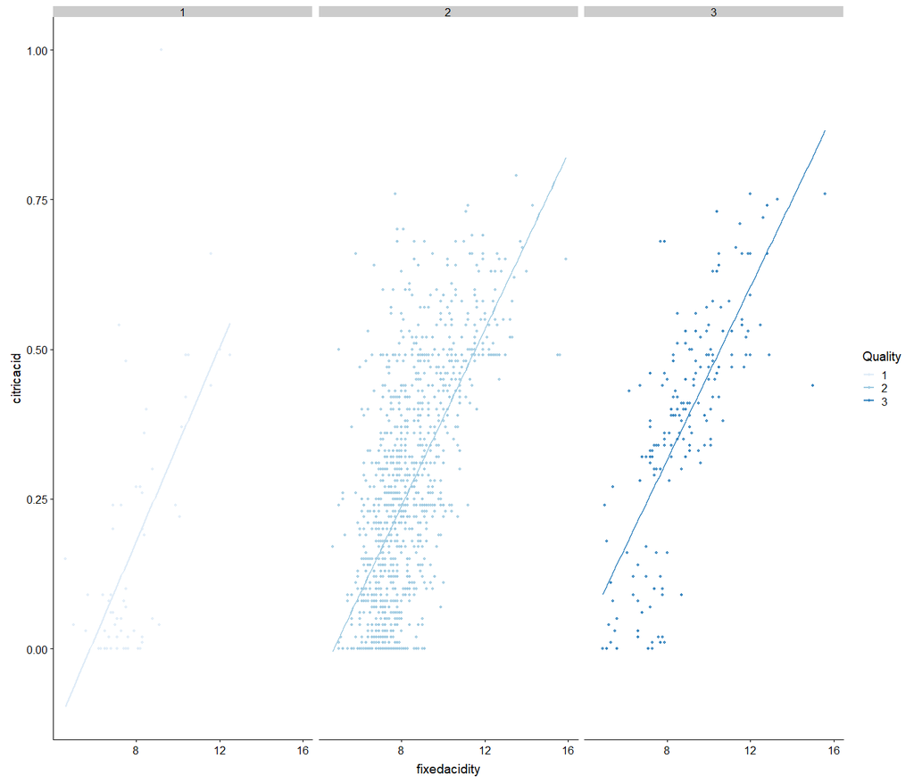

- **Ácido Cítrico (citricacid) vs Acidez Voláil (volatileacidity) = -0.55**

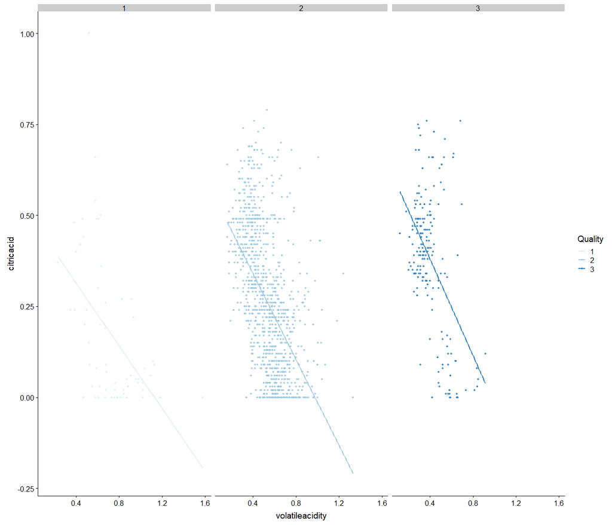

### 1.4.7 Todos os Vinhos (Análise das Correlações)

Após analisarmos os dados, percebemos que o tipo do vinho (Vinho) tem correlações significativas com algumas propriedades, como por exemplo:  
**- Acidez Voláil (volatileacidity) = -0.65**  
**- Cloretos (chlorides) = -0.51**  
**- Dióxido de Enxofre Total (totalsulfurdioxide) = 0.70**

- **Acidez Voláil (volatileacidity) = -0.65**

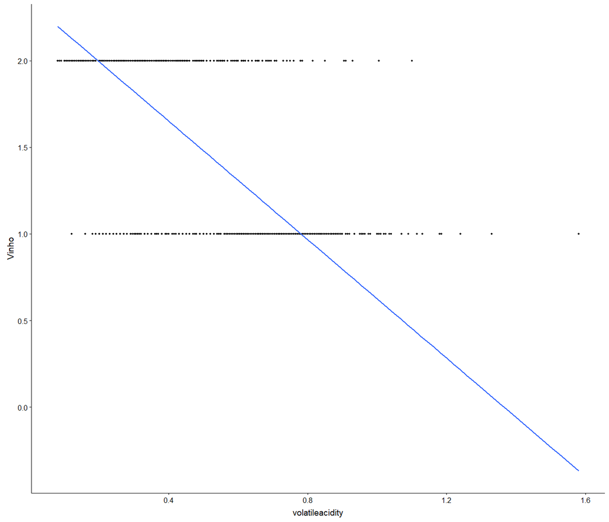

- **Cloretos (chlorides) = -0.51**

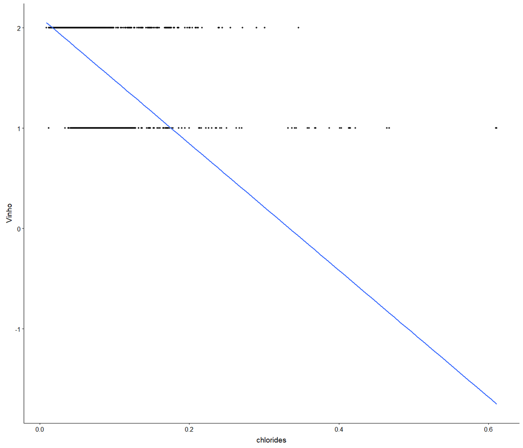

- **Dióxido de Enxofre Total (totalsulfurdioxide) = 0.70**

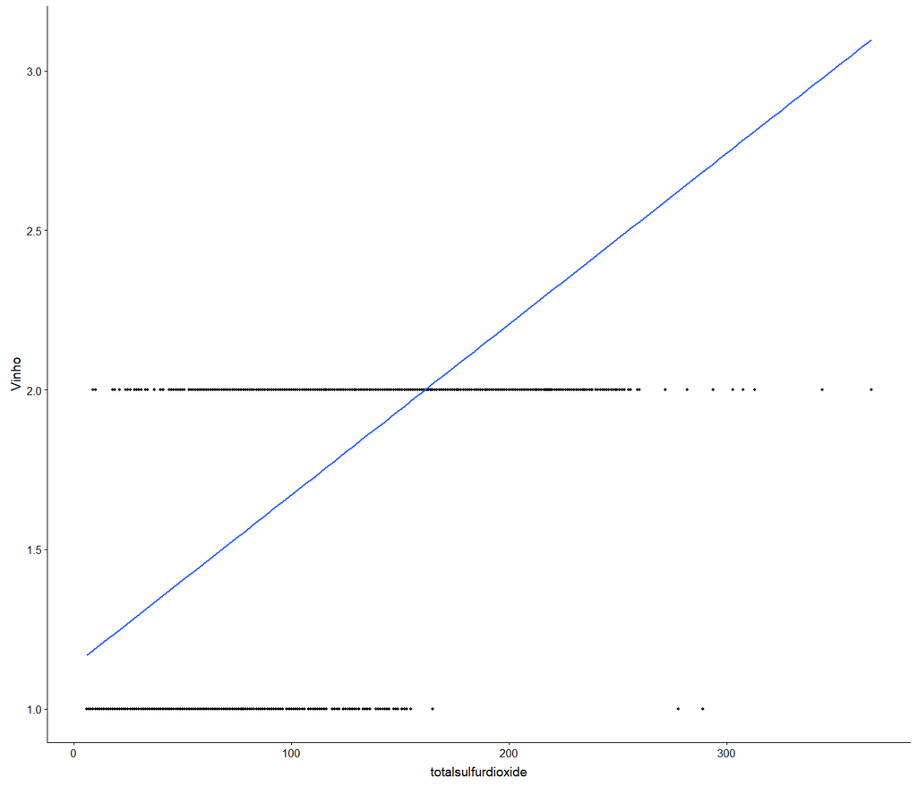

Para os dois tipos de vinhos, um ponto que chamou nossa atenção é que não encontramos uma correlação positiva forte entre o pH e a Acidez Volátil. Este ponto nos deixo muito curiosos já que quanto menor o pH, maior é a acidez. Dessa forma aprofundamos essa investigação e descobrimos a existencia de uma fenômeno chamado **Simpson Paradox**.

> “O paradoxo de Simpson (ou reversão de Simpson, efeito Yule-Simpson, paradoxo de amalgamação ou paradoxo de reversão) [1] é um fenômeno em probabilidade e estatística, em que uma tendência aparece em vários grupos diferentes de dados, mas desaparece ou reverte quando esses grupos são combinados . Este resultado é freqüentemente encontrado em estatísticas de ciências sociais e ciências médicas [2] [3] [4] e é particularmente problemático quando dados de frequência são indevidamente dadas interpretações causais. [5] O paradoxo pode ser resolvido quando as relações causais são apropriadamente atendidas na modelagem estatística. [5] [6] Ele tem sido usado para tentar informar o público não especialista ou público sobre o tipo de resultados enganosos que estatísticas erradas podem gerar. [7] [8] Martin Gardner escreveu um relato popular do paradoxo de Simpson em sua coluna de Jogos Matemáticos de março de 1976 na revista Scientific American. [9]”

(fonte: https://en.wikipedia.org/wiki/Simpson%27s_paradox)